# WriteUp

Tomas Fontecilla

Sunday, October 26, 2014

This is the submission for the Data Science certification, Practical Data Mining course.

## Background

Using devices such as Jawbone Up, Nike FuelBand, and Fitbit it is now possible to collect a large amount of data about personal activity relatively inexpensively. These type of devices are part of the quantified self movement – a group of enthusiasts who take measurements about themselves regularly to improve their health, to find patterns in their behavior, or because they are tech geeks. One thing that people regularly do is quantify how much of a particular activity they do, but they rarely quantify how well they do it. In this project, your goal will be to use data from accelerometers on the belt, forearm, arm, and dumbell of 6 participants. They were asked to perform barbell lifts correctly and incorrectly in 5 different ways. More information is available from the website here: http://groupware.les.inf.puc-rio.br/har (see the section on the Weight Lifting Exercise Dataset).

After setting the work directory, first step should be to download the data:

- train data url: `fileUrl = 'https://d396qusza40orc.cloudfront.net/predmachlearn/pml-training.csv'`
- test data url: `fileUrlTest = 'https://d396qusza40orc.cloudfront.net/predmachlearn/pml-testing.csv'`
- download train data: `download.file(fileUrl,destfile='ProjectData.csv')`
- download test data:`download.file(fileUrlTest,destfile=‘ProjectTestData.csv’)`

```r
trainData=read.table('ProjectData.csv',header=TRUE,sep=',',na.strings=c('','NA','NULL','#DIV/0!'))
testData=read.csv('ProjectTestData.csv',header=TRUE,sep=',',na.strings=c('','NA','NULL','#DIV/0!'))
```

Taking the `na.strings=c('','NA','NULL','#DIV/0!')` ensures that this four types of strings are registered for our analysis as Non Available data.

The libraries we are going to use for this project needs to be loaded, so:

```r
library(caret)
```

```r
library(corrplot)
```

## Cleaning the Data:

As such, we get:

```r
dim(trainData)
```

```
## [1] 19622   160
```

```r
trainData<-trainData[,colSums((is.na(trainData)))<0.9*nrow(trainData)]

nonValueAddColumns = c('raw_timestamp_part_1', 'raw_timestamp_part_2', 'cvtd_timestamp', 'new_window', 'num_window', 'X', 'user_name')
trainData<-trainData[,-which(names(trainData)%in%nonValueAddColumns)]
dim(trainData)
```

```
## [1] 19622    53
```

We only are going to work with 53 columns.

## Reproducibility

```r
set.seed(134)
trainId = createDataPartition(trainData$classe,p=0.8,list=FALSE)
trainingData <-trainData[trainId,]
validation<-trainData[-trainId,]
```

## Analysis

The following graph shows the correlation matrix of the data to be analized

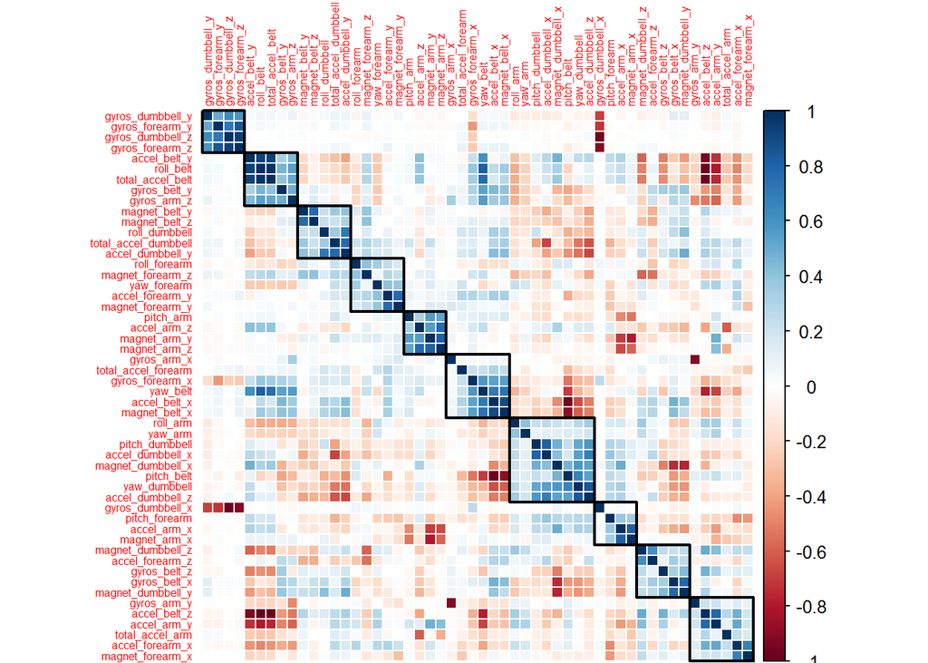

```r
correlationData <- cor(subset(trainData, select=-c(classe)))
corrplot(correlationData, order="hclust", tl.cex=0.5, method="color", insig = "pch", addrect = 10)
```

```r
#linear discriminant analysis
names(trainData)
```

```
##  [1] "roll_belt"            "pitch_belt"           "yaw_belt"
##  [4] "total_accel_belt"     "gyros_belt_x"         "gyros_belt_y"
##  [7] "gyros_belt_z"         "accel_belt_x"         "accel_belt_y"
## [10] "accel_belt_z"         "magnet_belt_x"        "magnet_belt_y"
## [13] "magnet_belt_z"        "roll_arm"             "pitch_arm"
## [16] "yaw_arm"              "total_accel_arm"      "gyros_arm_x"
## [19] "gyros_arm_y"          "gyros_arm_z"          "accel_arm_x"
## [22] "accel_arm_y"          "accel_arm_z"          "magnet_arm_x"
## [25] "magnet_arm_y"         "magnet_arm_z"         "roll_dumbbell"
## [28] "pitch_dumbbell"       "yaw_dumbbell"         "total_accel_dumbbell"
## [31] "gyros_dumbbell_x"     "gyros_dumbbell_y"     "gyros_dumbbell_z"
## [34] "accel_dumbbell_x"     "accel_dumbbell_y"     "accel_dumbbell_z"
## [37] "magnet_dumbbell_x"    "magnet_dumbbell_y"    "magnet_dumbbell_z"
## [40] "roll_forearm"         "pitch_forearm"        "yaw_forearm"
## [43] "total_accel_forearm"  "gyros_forearm_x"      "gyros_forearm_y"
## [46] "gyros_forearm_z"      "accel_forearm_x"      "accel_forearm_y"
## [49] "accel_forearm_z"      "magnet_forearm_x"     "magnet_forearm_y"
## [52] "magnet_forearm_z"     "classe"
```

```r
ldaModel<-train(classe~.,method='lda',data=trainData)
rfModel<-train(classe~.,method='rf',data=trainData)
ldaPred<-predict(ldaModel,newdata=validation)
rfPred<-predict(rfModel,newdata=validation)
```

The confusion Matrices for these models are:

```r
confusionMatrix(ldaPred,validation$classe)
```

```
## Confusion Matrix and Statistics
##
##           Reference
## Prediction   A   B   C   D   E
##          A 904 104  72  30  28
##          B  26 503  71  23 133
##          C  88  97 443  79  64
##          D  95  25  80 484  73
##          E   3  30  18  27 423
##
## Overall Statistics
##
##                Accuracy : 0.7028
##                  95% CI : (0.6882, 0.7171)
##     No Information Rate : 0.2845
##     P-Value [Acc > NIR] : < 2.2e-16
##
##                   Kappa : 0.6242
##  Mcnemar's Test P-Value : < 2.2e-16
##
## Statistics by Class:
##
##                      Class: A Class: B Class: C Class: D Class: E
## Sensitivity            0.8100   0.6627   0.6477   0.7527   0.5867
## Specificity            0.9166   0.9200   0.8987   0.9168   0.9756
## Pos Pred Value         0.7944   0.6653   0.5746   0.6394   0.8443
## Neg Pred Value         0.9239   0.9192   0.9235   0.9498   0.9129
## Prevalence             0.2845   0.1935   0.1744   0.1639   0.1838
## Detection Rate         0.2304   0.1282   0.1129   0.1234   0.1078
## Detection Prevalence   0.2901   0.1927   0.1965   0.1930   0.1277
## Balanced Accuracy      0.8633   0.7914   0.7732   0.8347   0.7812
```

```r
confusionMatrix(rfPred,validation$classe)
```

```
## Confusion Matrix and Statistics
##
##           Reference
## Prediction    A    B    C    D    E
##          A 1116    0    0    0    0
##          B    0  759    0    0    0
##          C    0    0  684    0    0
##          D    0    0    0  643    0
##          E    0    0    0    0  721
##
## Overall Statistics
##
##                Accuracy : 1
##                  95% CI : (0.9991, 1)
##     No Information Rate : 0.2845
##     P-Value [Acc > NIR] : < 2.2e-16
##
##                   Kappa : 1
##  Mcnemar's Test P-Value : NA
##
## Statistics by Class:
##
##                      Class: A Class: B Class: C Class: D Class: E
## Sensitivity            1.0000   1.0000   1.0000   1.0000   1.0000
## Specificity            1.0000   1.0000   1.0000   1.0000   1.0000
## Pos Pred Value         1.0000   1.0000   1.0000   1.0000   1.0000
## Neg Pred Value         1.0000   1.0000   1.0000   1.0000   1.0000
## Prevalence             0.2845   0.1935   0.1744   0.1639   0.1838
## Detection Rate         0.2845   0.1935   0.1744   0.1639   0.1838
## Detection Prevalence   0.2845   0.1935   0.1744   0.1639   0.1838
## Balanced Accuracy      1.0000   1.0000   1.0000   1.0000   1.0000
```

The model with the best accuracy is the generated by Random Forest.

```r
accuracy_lda<-c(as.numeric(predict(ldaModel,newdata=validation[,-ncol(validation)])==validation$classe))
accuracy<-sum(accuracy_lda)*100/nrow(validation)
print(accuracy_lda)
```

[output not shown]

[output cut: 101 more lines]

```r
accuracy_rf<-c(as.numeric(predict(rfModel,newdata=validation[,-ncol(validation)])==validation$classe))
accuracy<-sum(accuracy_rf)*100/nrow(validation)
print(accuracy_rf)
```

[output not shown]

[output cut: 101 more lines]

## Prediction

As the model with better accuracy is the Random Forest classification model, this is the one we are going to use.

```r
testData<-testData[,-1]
predictions<-predict(rfModel,newdata=testData)
print(predictions)
```

```
##  [1] B A B A A E D B A A B C B A E E A B B B
## Levels: A B C D E
```

Been this the values we are looking for, we need to write them to complete the project

```r
pml_write_files = function(x){
  n = length(x)
  if(!file.exists('answers')){
    dir.create('answers')
  }
  for(i in 1:n){
    filename = paste0("./answers/problem_id_",i,".txt")
    write.table(x[i],file=filename,quote=FALSE,row.names=FALSE,col.names=FALSE)
  }
}

pml_write_files(predictions)
```